# PCOD

[figure not shown]

```r
boxplot(data$PCOS..Y.N. ~ data$BMI,
        main = "BMI across various cases of PCOS",
        xlab = "PCOS",
        ylab = "BMI",
        col = c("lightgreen", "lightcoral"))
```

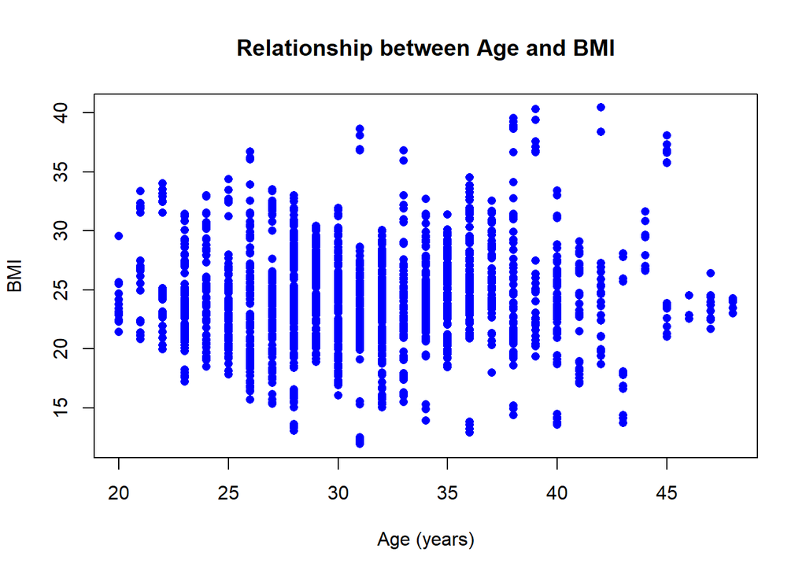

```r
plot(data$Age, data$BMI,
     main = "Relationship between Age and BMI",
     xlab = "Age (years)",
     ylab = "BMI",
     col = "blue",
     pch = 16)
```

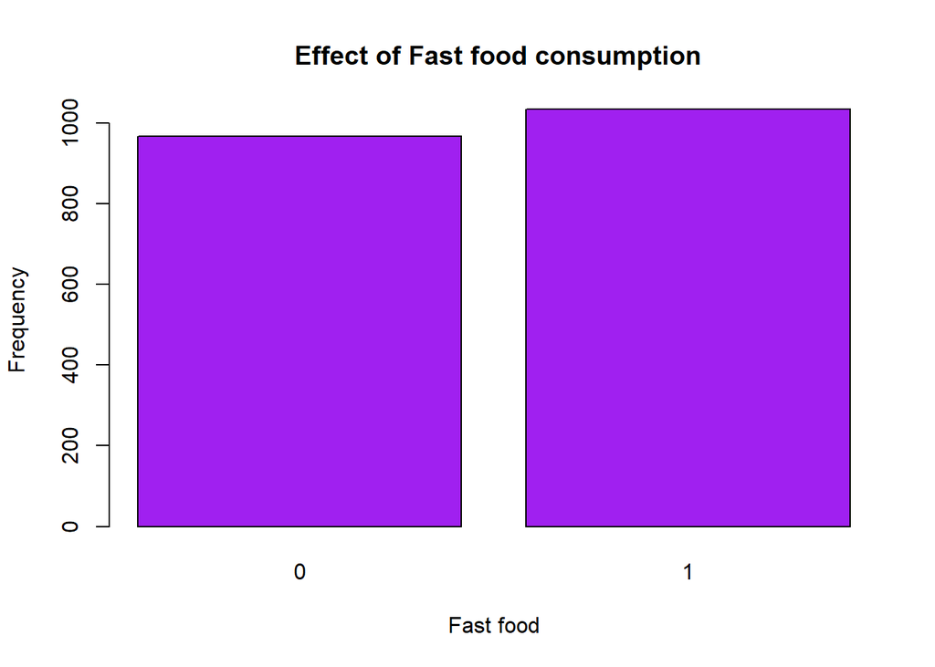

```r
barplot(table(data$Fast.food..Y.N.),
        main = " Effect of Fast food consumption",
        xlab = "Fast food",
        ylab = "Frequency",
        col = "purple",
        border = "black")
```

##The plot shows the effect of fast food consumption. The x-axis represents fast food consumption (yes or no), and the y-axis represents frequency. The bar plot shows that a majority of individuals in the dataset consume fast food.

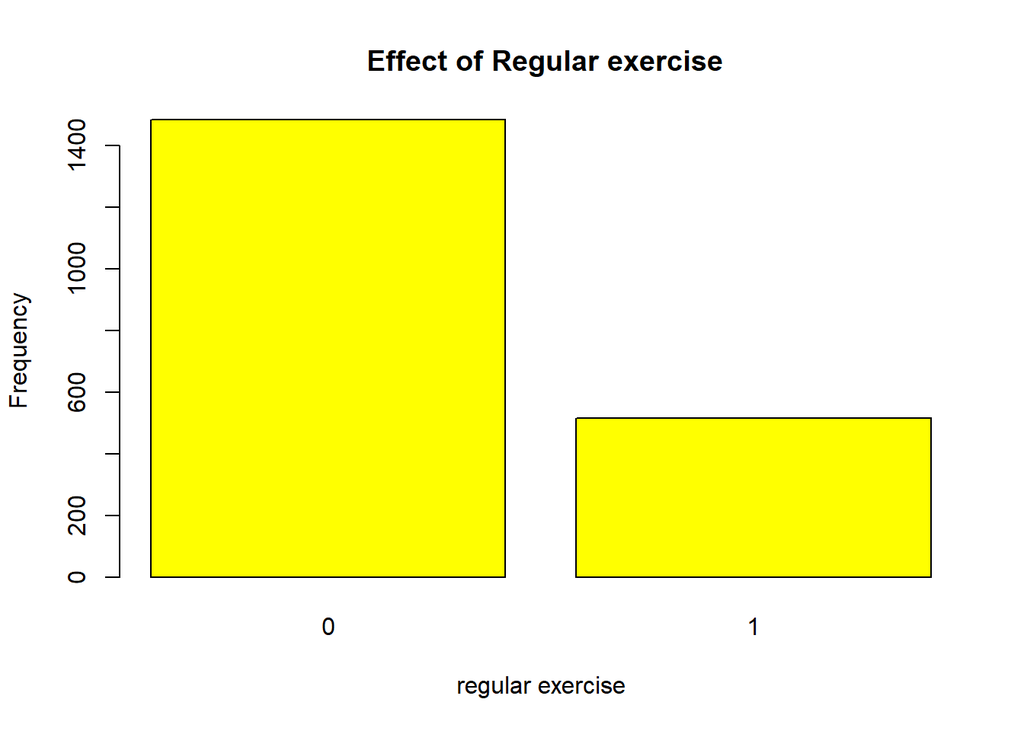

```r
barplot(table(data$Reg.Exercise.Y.N.),
        main = " Effect of Regular exercise",
        xlab = "regular exercise",
        ylab = "Frequency",
        col = "yellow",
        border = "black")
```

##The plot shows the effect of regular exercise. The x-axis represents regular exercise (yes or no), and the y-axis represents frequency. The bar plot shows that a majority of individuals in the dataset do not engage in regular exercise.